# SOC 325 Lab 3 - Analyzing the Sleep Survey

Soc 325: Quantified-Self

Kim Nguyen

2023-02-03

# Pyschology of R, RStudio and Labs

Scripting is HARD. That is ok, many hard things are useful! This is very helpful if you want to work as a data scientist. You need to familiarize yourself with the practices of coding and building analysis scripts.

**Why**

- Your work has to be reproducible
- Your work has to be able to hand off to someone else
- You need to be able to do lots of different things

**You Don’t need to do everything from scratch!!**

- It is ok to borrow code, use [stack overflow](https://stackoverflow.com/), [google](https://google.com), etc.
- Use books like [R for Data Science](https://r4ds.had.co.nz/introduction.html).

**Strategies for working in RMarkdown**

- DO **NOT** code a bunch and then *knit* – This will almost assuredly not work and crash!
- Do make small changes and *knit*
  - If you have a part that takes a long time (e.g. reading in data) turn `cache=TRUE` on in the R Chunk. This will pre-load it and make it faster.

# ATUS Sleep Score and Review of R Code

## Load Libraries Needed For this Lab

For library management we use use the library `pacman`. The key with pacman is it will install and load the packages if needed. This makes our life easier!

The first line of code is `if (!require("pacman")) install.packages("pacman")` to install pacman if needed.

The second line `pacman::p_load([PACKAGES HERE])` uses `pacman` to load and install all the packages for the lab.

```r
## Run this code, to manage packages and install as needed.
# Install pacman
if (!require("pacman")) install.packages("pacman")
# p_load function loads packages if installed, or install then loads otherwise
pacman::p_load(tidyverse,googlesheets4,haven,lubridate,ggthemes,AMR,kableExtra,here)
```

## Review the R Coded Needed for this lab

The first part of this lab is to review and introduce all the key R and tidyverse functions we need for the lab.

## Data Import

In this section we are going to get experience pulling from Google Sheets. To do this we will use the `googlesheets4` package load the data from Google sheets.

- This process takes a little bit of time.
- It will make you sign into your UW Gmail account.
- `cache=TRUE` is turned on so you don’t have to download the data again and again.

We will use the `read_sheet([URL TO SHEET HERE])` to get the sheet information. Run this code for the first time directly in the *Console* to work through the sign in process.

```r
atus<- read_sheet("https://docs.google.com/spreadsheets/d/1SlgdikWNHnboJJOOs9RM0s0_VvM5NFu9_9ftcnPsjGU/edit?usp=sharing")
atus
```

```
## # A tibble: 113,652 × 11
##     CASEID  YEAR STATEFIP METAREA PERNUM LINENO      WT06   AGE   SEX EMPSTAT
##      <dbl> <dbl>    <dbl>   <dbl>  <dbl>  <dbl>     <dbl> <dbl> <dbl>   <dbl>
##  1 2.01e13  2005        5       0      1      1 12064433.    51     2       4
##  2 2.01e13  2005        6    4481      1      1  5434077.    42     2       1
##  3 2.01e13  2005        6       0      1      1 15341381.    47     1       1
##  4 2.01e13  2005       17    1601      1      1  3110324.    21     2       1
##  5 2.01e13  2005       17    1601      1      1  8828106.    49     2       5
##  6 2.01e13  2005       17       0      1      1  4402800.    44     1       5
##  7 2.01e13  2005       17    1601      1      1 13347375.    46     1       1
##  8 2.01e13  2005       22       0      1      1  6857422.    24     2       1
##  9 2.01e13  2005       36    5601      1      1  3867232.    30     2       5
## 10 2.01e13  2005       39    1681      1      1 14191443.    26     1       1
## # … with 113,642 more rows, and 1 more variable: BLS_PCARE_SLEEP <dbl>
```

## Data Cleaning and munging

First thing after we load the data is we need to clean it!

- Clean `SEX` so that 1 is Male and 2 is Female.
- Create five year age groups. To do this we will use the `AMR` package function `age_groups`, `AMR::age_groups(x,"fives")`.

To do this we will use the tidyverse format:

Object %>% verb

In this case

`atus%>%mutate([ACTION HERE])`

```r
# Create a new variable sex, where we rcode 1 to Male and 2 to Female
# Create a new variable age_group = age_groups(AGE,"fives") five year
# age groups
atus1<- atus %>%
  mutate(
   sex = if_else(SEX==1, "Male", "Female"),
   age_group = age_groups(AGE,"fives")
 )

atus1
```

```
## # A tibble: 113,652 × 13
##     CASEID  YEAR STATEFIP METAREA PERNUM LINENO      WT06   AGE   SEX EMPSTAT
##      <dbl> <dbl>    <dbl>   <dbl>  <dbl>  <dbl>     <dbl> <dbl> <dbl>   <dbl>
##  1 2.01e13  2005        5       0      1      1 12064433.    51     2       4
##  2 2.01e13  2005        6    4481      1      1  5434077.    42     2       1
##  3 2.01e13  2005        6       0      1      1 15341381.    47     1       1
##  4 2.01e13  2005       17    1601      1      1  3110324.    21     2       1
##  5 2.01e13  2005       17    1601      1      1  8828106.    49     2       5
##  6 2.01e13  2005       17       0      1      1  4402800.    44     1       5
##  7 2.01e13  2005       17    1601      1      1 13347375.    46     1       1
##  8 2.01e13  2005       22       0      1      1  6857422.    24     2       1
##  9 2.01e13  2005       36    5601      1      1  3867232.    30     2       5
## 10 2.01e13  2005       39    1681      1      1 14191443.    26     1       1
## # … with 113,642 more rows, and 3 more variables: BLS_PCARE_SLEEP <dbl>,
## #   sex <chr>, age_group <ord>
```

### Let’s look at Seattle, SF, LA, NY, Boston, DC Metros sleep pattern

- In the ATUS `METAREA` has codes for [US Metropolitan statistical areas](https://en.wikipedia.org/wiki/Metropolitan_statistical_area).

To do this we will filter Seattle, SF, LA, NY, Boston, DC Metros and then we we will code the numeric metro names to readable metro names (e.g. Seattle Metro).

Again, we will use the object pipe verb formate (object%>%verb). In this case

`atus%>%filter([FILTER LOGICAL EXPRESSION]`

In this case we want to `filter` to limit the rows that SF, LA, NY, Boston, DC Metros.

- 7601 is Seattle Metro
- 7360 is SF Metro
- 4481 is LA Metro
- 5601 is NY metro
- 1121 is Boston Metro
- 8841 is DC Metro

To do this we need to keep (`TRUE`) all of these metros (`c(7601,7360,4481, 5601,1121,8841)`). We can do this with an `%in%` operator which works as `[variable] %in% [SET]`. The `%in%` operator works as follows it checks to see if thing in SET exists in each row in the VARIABLE. Let’s do a small example:

```r
## Create example
VAR<-letters
SET<-c("z","a","c","k")
## See the logical statement
VAR%in%SET
```

```
##  [1]  TRUE FALSE  TRUE FALSE FALSE FALSE FALSE FALSE FALSE FALSE  TRUE FALSE
## [13] FALSE FALSE FALSE FALSE FALSE FALSE FALSE FALSE FALSE FALSE FALSE FALSE
## [25] FALSE  TRUE
```

```r
## Veify it selects what expect
### Notice order is in the VARIABLE object
letters[VAR%in%SET]
```

```
## [1] "a" "c" "k" "z"
```

Let’s do this now for our ATUS data,

```r
atus_metro<-atus1%>%filter(METAREA%in%c(7601,7360,4481, 5601,1121,8841))
```

To MAP the NUMERIC (e.g. 7601) to STRING (e.g. “Seattle Metro”) we will use the `case_when` function, that works as follows:

```
case_when(
    METAREA==7601~"Seattle Metro",
    METAREA==7360~"SF Metro",
    METAREA==4481~"LA Metro",
    METAREA==5601~"NY Metro",
    METAREA==1121~"Boston Metro",
    METAREA==8841~"DC Metro"
  )
```

Now, lets put all this together, `object%>%verb` `atus_metro%>%mutate(case_when))` format:

```r
atus_metro<-atus_metro%>%mutate(
  location = case_when(
    METAREA==7601~"Seattle Metro",
    METAREA==7360~"SF Metro",
    METAREA==4481~"LA Metro",
    METAREA==5601~"NY Metro",
    METAREA==1121~"Boston Metro",
    METAREA==8841~"DC Metro"
  )
)

## Print out to see if it worked
atus_metro
```

```
## # A tibble: 21,195 × 14
##     CASEID  YEAR STATEFIP METAREA PERNUM LINENO      WT06   AGE   SEX EMPSTAT
##      <dbl> <dbl>    <dbl>   <dbl>  <dbl>  <dbl>     <dbl> <dbl> <dbl>   <dbl>
##  1 2.01e13  2005        6    4481      1      1  5434077.    42     2       1
##  2 2.01e13  2005       36    5601      1      1  3867232.    30     2       5
##  3 2.01e13  2005        6    7360      1      1  4530086.    15     1       5
##  4 2.01e13  2005        6    4481      1      1  3284994.    46     1       1
##  5 2.01e13  2005        6    4481      1      1  6420665.    15     2       4
##  6 2.01e13  2005        6    4481      1      1  7640587.    80     2       5
##  7 2.01e13  2005        6    4481      1      1  8252945.    15     1       5
##  8 2.01e13  2005        6    4481      1      1  1497881.    26     1       1
##  9 2.01e13  2005        6    4481      1      1  7447516.    66     1       5
## 10 2.01e13  2005        6    4481      1      1 10714514.    30     2       1
## # … with 21,185 more rows, and 4 more variables: BLS_PCARE_SLEEP <dbl>,
## #   sex <chr>, age_group <ord>, location <chr>
```

## Data Summaries

The ATUS is “weighted” survey. So to make the marginals we will need to compute the weighted version. This can be done with the following equations

$$\bar{X} = \sum_{i=1}^n
\frac{w_i}{\sum_{i=1}^n w_i } x_i = \frac{\sum_{i=1}^n w_i\times x_i
}{\sum_{i=1}^n w_i}$$

We can do this using the tidyverse `summarise()` function and `group_by()` function. We want to see the age by location cross tab for sleep.

### Age by Location Summary

First, we want to `group_by()` `age_group` and`location` [`group_by(age_group,location)`]. Then we want to `summarise()` by Hours Slept:

```r
sleep_summary<-atus_metro%>%group_by(age_group,location)%>%summarise(
  sleep=sum(BLS_PCARE_SLEEP*WT06),
  total=sum(WT06),
  asleep_min = sleep/total,
  asleep_hour =  asleep_min/60 ## divide by 60 to get hours
  )

## Print out see what we did
sleep_summary
```

```
## # A tibble: 90 × 6
## # Groups:   age_group [15]
##    age_group location        sleep       total asleep_min asleep_hour
##    <ord>     <chr>           <dbl>       <dbl>      <dbl>       <dbl>
##  1 15-19     Boston Metro  6.25e11 1063155246.       588.        9.80
##  2 15-19     DC Metro      1.04e12 1838450569.       564.        9.40
##  3 15-19     LA Metro      2.99e12 5164011419.       579.        9.66
##  4 15-19     NY Metro      2.30e12 3985469331.       577.        9.62
##  5 15-19     Seattle Metro 4.90e11  844009790.       581.        9.68
##  6 15-19     SF Metro      1.18e12 2102012647.       563.        9.38
##  7 20-24     Boston Metro  6.09e11 1122164593.       543.        9.05
##  8 20-24     DC Metro      6.96e11 1253771723.       555.        9.25
##  9 20-24     LA Metro      2.15e12 3810224771.       564.        9.40
## 10 20-24     NY Metro      2.35e12 4354081190.       539.        8.98
## # … with 80 more rows
```

We are going to select out (`object%>%select(var1,...,vark)`) variables and `spread` to get `location` by `age_group` with `asleep_hour`

```r
ct<-sleep_summary%>%
  select(location,age_group,asleep_hour)%>%
  spread(key=age_group,asleep_hour)
```

Next we are going print out the cross tabs use `kableExtra` package which has a lot of great features, if you want to play with you can find information, [here](https://cran.r-project.org/web/packages/kableExtra/vignettes/awesome_table_in_html.html)

```r
## Cross Tab Table
ct%>%kbl(digits = 2) %>%
  kable_styling()%>%
   kable_paper("hover", full_width = F)
```

| location | 15-19 | 20-24 | 25-29 | 30-34 | 35-39 | 40-44 | 45-49 | 50-54 | 55-59 | 60-64 | 65-69 | 70-74 | 75-79 | 80-84 | 85-89 |
| --- | --- | --- | --- | --- | --- | --- | --- | --- | --- | --- | --- | --- | --- | --- | --- |
| Boston Metro | 9.80 | 9.05 | 8.87 | 8.67 | 8.26 | 8.14 | 8.23 | 8.33 | 8.07 | 8.31 | 8.81 | 8.34 | 8.79 | 8.62 | 9.19 |
| DC Metro | 9.40 | 9.25 | 8.77 | 8.58 | 8.32 | 8.27 | 8.17 | 8.31 | 8.14 | 8.22 | 8.54 | 8.53 | 8.51 | 8.70 | 10.29 |
| LA Metro | 9.66 | 9.40 | 8.66 | 8.77 | 8.59 | 8.80 | 8.42 | 8.38 | 8.44 | 8.47 | 8.75 | 8.89 | 9.30 | 9.25 | 9.26 |
| NY Metro | 9.62 | 8.98 | 8.70 | 8.65 | 8.32 | 8.26 | 8.31 | 8.04 | 8.37 | 8.35 | 8.60 | 8.80 | 8.98 | 8.94 | 9.57 |
| Seattle Metro | 9.68 | 8.00 | 8.87 | 8.43 | 8.42 | 8.49 | 8.45 | 8.50 | 8.30 | 8.69 | 8.63 | 9.02 | 8.28 | 9.34 | 10.10 |
| SF Metro | 9.38 | 9.16 | 8.63 | 8.60 | 8.24 | 8.51 | 8.40 | 8.13 | 8.46 | 8.04 | 8.54 | 8.54 | 9.01 | 9.85 | 10.05 |

## Data Plotting

Let’s plot the cross tab as matrix plot. We will use the `geom_tile()` to do this. Remember that format of `ggplot()`

```
object %>% ggplot(aes(X,Y,[fill,group,color]))+
          geom_FUNCTION()+
          theme_NAME()+
          ...[OTHER LAYERS]
```

Below is an example using the `geom_tile()`:

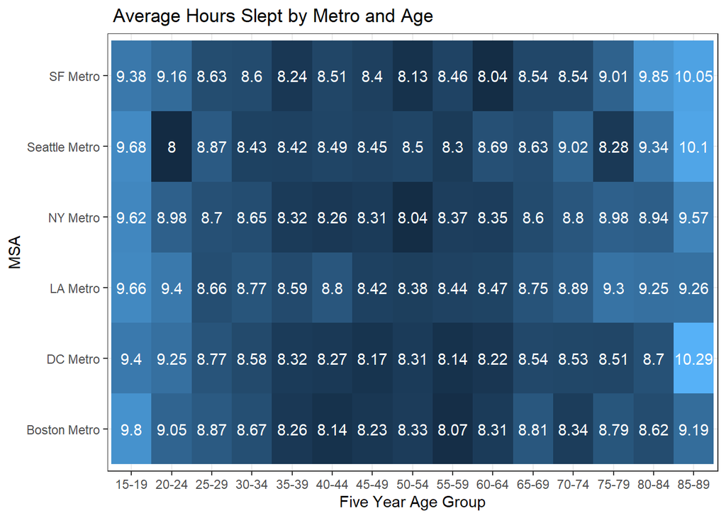

```r
## Matrix Plot
sleep_summary%>%ggplot(aes(age_group, location, fill= asleep_hour)) +
  geom_tile()+
  theme_bw()+
  geom_text(aes(label = round(asleep_hour,2)), colour="#FFFFFF")+
  theme(legend.position="none")+
  ggtitle(" Average Hours Slept by Metro and Age")+
  xlab("Five Year Age Group")+
  ylab("MSA")
```

# Class Sleep Survey

You’ll download all R and RMarkdown files of the lab files for this class as `.zip` files from Google Drive.

## Load Data

```r
demographics<-read_sheet("https://docs.google.com/spreadsheets/d/1vrYgMFticTh2kwjtdfFq8mMJ2__v46iAhOl7wPj-byo/edit?usp=share_link")

chrono_type<-read_sheet("https://docs.google.com/spreadsheets/d/1Ba7DEMgMK0wTS-kR9DtPNC4GWROpL_1Zc-GXSa1fqpc/edit?usp=sharing")

daily_sleep_log<-read_sheet("https://docs.google.com/spreadsheets/d/1hcF1adwpeuJRKWZr12KDV2nMZ0a3F9kivGb25Xl6glo/edit?usp=sharing")
```

## Explore Data

### Box plot of sleep log data

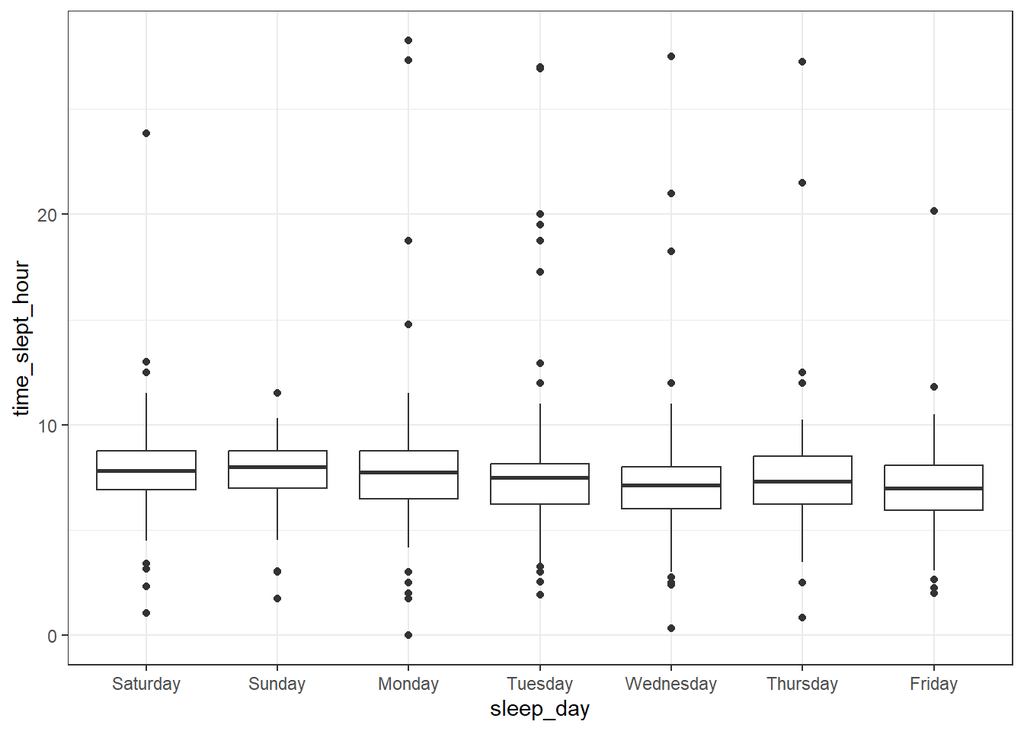

```r
daily_sleep_log%>%mutate(
    sleep_day=
      as.factor(sleep_day)%>% ## Relevel factor so it displays Saturday to Friday
      fct_relevel(levels(as.factor(sleep_day))[c(3,4,2,6,7,5,1)])
)%>%
    ggplot(aes(x=sleep_day,y=time_slept_hour))+
    geom_boxplot()+theme_bw()
```

### Summary tables

```r
## Average hours slept by day of the week
daily_sleep_log%>%group_by(sleep_day)%>%summarise(ats=mean(time_slept_hour))
```

```
## # A tibble: 7 × 2
##   sleep_day   ats
##   <chr>     <dbl>
## 1 Friday     7.16
## 2 Monday     7.90
## 3 Saturday   7.85
## 4 Sunday     7.75
## 5 Thursday   7.43
## 6 Tuesday    7.74
## 7 Wednesday  7.34
```

```r
## Count by Race
demographics%>%group_by(race)%>%count()
```

```
## # A tibble: 3 × 2
## # Groups:   race [3]
##   race      n
##   <chr> <int>
## 1 Asian    24
## 2 Other     8
## 3 White    26
```

```r
## Count by gender
demographics%>%group_by(gender)%>%count()
```

```
## # A tibble: 3 × 2
## # Groups:   gender [3]
##   gender     n
##   <chr>  <int>
## 1 Female    41
## 2 Male      12
## 3 Other      5
```

```r
## Feel Best
chrono_type%>%group_by(FeelBest)%>%summarise(n=n())
```

```
## # A tibble: 5 × 2
##   FeelBest                   n
##   <chr>                  <int>
## 1 10:00 a.m. - 5:00 p.m.    30
## 2 10:00 p.m. - 5:00 a.m.     2
## 3 5:00 a.m. - 8:00 a.m.      1
## 4 5:00 p.m. - 10:00 p.m.    17
## 5 8:00 a.m. - 10:00 a.m.     8
```

```r
## Type - Morning Person, etc
chrono_type%>%group_by(type)%>%summarise(n=n())
```

```
## # A tibble: 4 × 2
##   type                                                n
##   <chr>                                           <int>
## 1 Definitely a morning type                           3
## 2 Definitely an evening type                         17
## 3 Rather more a morning type than an evening type    10
## 4 Rather more an evening type than a morning type    28
```

### Chronotype plot of preference of sleep and wake time

```r
ct_long<-chrono_type%>%pivot_longer(cols=c(std_sleep_weekday:std_wake_weekday,std_sleep_weekend:std_wake_weekend),
                  names_to="Sleep",values_to = "HourOfDay")%>%
                  mutate(
                    Sleep=str_remove(Sleep,"std_"),
                    Sleep=str_replace(Sleep,"_weekday"," Weekday"),
                    Sleep=str_remove(Sleep,"std_"),
                    Sleep=str_replace(Sleep,"_weekend"," Weekend"),
                    Sleep=str_to_title(Sleep),
                    HourOfDay=format(HourOfDay,"%H:%M:%S")
                  )%>%select(Sleep,HourOfDay)

ct_long
```

```
## # A tibble: 232 × 2
##    Sleep         HourOfDay
##    <chr>         <chr>
##  1 Sleep Weekday 01:30:00
##  2 Wake Weekday  07:00:00
##  3 Sleep Weekend 02:30:00
##  4 Wake Weekend  10:45:00
##  5 Sleep Weekday 02:30:00
##  6 Wake Weekday  08:00:00
##  7 Sleep Weekend 05:00:00
##  8 Wake Weekend  14:00:00
##  9 Sleep Weekday 00:30:00
## 10 Wake Weekday  09:00:00
## # … with 222 more rows
```

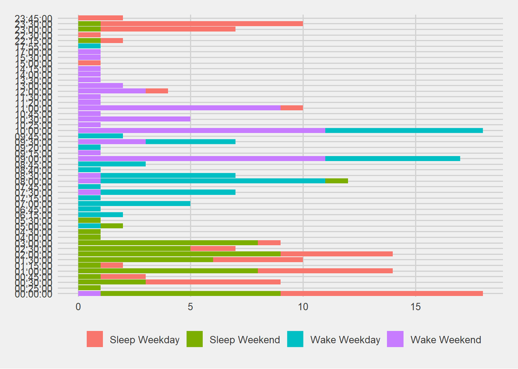

```r
ct_long%>%
  ggplot(aes(y=HourOfDay,fill=Sleep))+
  geom_bar()+
  scale_color_fivethirtyeight() +
  theme_fivethirtyeight()+
  ylab("Hour of the Day")+
  xlab("Count")+
  guides(fill=guide_legend(title=""))
```

# Part 1

## Question 1.1

Link the demographics (`demographics`) and chrono type (`chrono_type`) data sets. *hint* use `left_join`.

YOUR SOLUTION HERE

```r
data1 <- left_join(demographics, chrono_type, by="random_id")

data1
```

```
## # A tibble: 58 × 15
##    random…¹ gender race  in_cl…² working std_sleep_weekday   std_wake_weekday
##       <dbl> <chr>  <chr> <chr>   <chr>   <dttm>              <dttm>
##  1       25 Female White Yes     Yes     1899-12-30 01:30:00 1899-12-30 07:00:00
##  2       39 Male   Other Yes     Yes     1899-12-30 00:30:00 1899-12-30 09:00:00
##  3       20 Male   Asian Yes     Yes     1899-12-30 23:45:00 1899-12-30 08:40:00
##  4       15 Female Asian Yes     No      1899-12-30 02:30:00 1899-12-30 09:30:00
##  5       19 Female White Yes     Yes     1899-12-30 22:15:00 1899-12-30 07:15:00
##  6       47 Female White Yes     Yes     1899-12-30 00:00:00 1899-12-30 07:00:00
##  7       55 Female Other Yes     No      1899-12-30 00:45:00 1899-12-30 08:45:00
##  8       11 Other  White Yes     No      1899-12-30 23:00:00 1899-12-30 07:30:00
##  9       38 Female Asian Yes     Yes     1899-12-30 22:30:00 1899-12-30 09:00:00
## 10       50 Female Asian Yes     Yes     1899-12-30 00:30:00 1899-12-30 07:45:00
## # … with 48 more rows, 8 more variables: hour_sleep_weekday <dbl>,
## #   hour_wake_up_weekday <dbl>, std_sleep_weekend <dttm>,
## #   std_wake_weekend <dttm>, hour_sleep_weekend <dbl>,
## #   hour_wake_up_weekend <dbl>, FeelBest <chr>, type <chr>, and abbreviated
## #   variable names ¹random_id, ²in_class
```

END OF YOUR SOLUTION HERE

## Question 1.2

Take your linked data and create summary tables of `FeelBest` and `type` by `gender`.

YOUR SOLUTION HERE

```r
summarize1<- data1 %>%
  summarize(FeelBest, type, gender)
```

END OF YOUR SOLUTION HERE

## Question 1.3

Build a bar chart of type by gender.

YOUR SOLUTION HERE

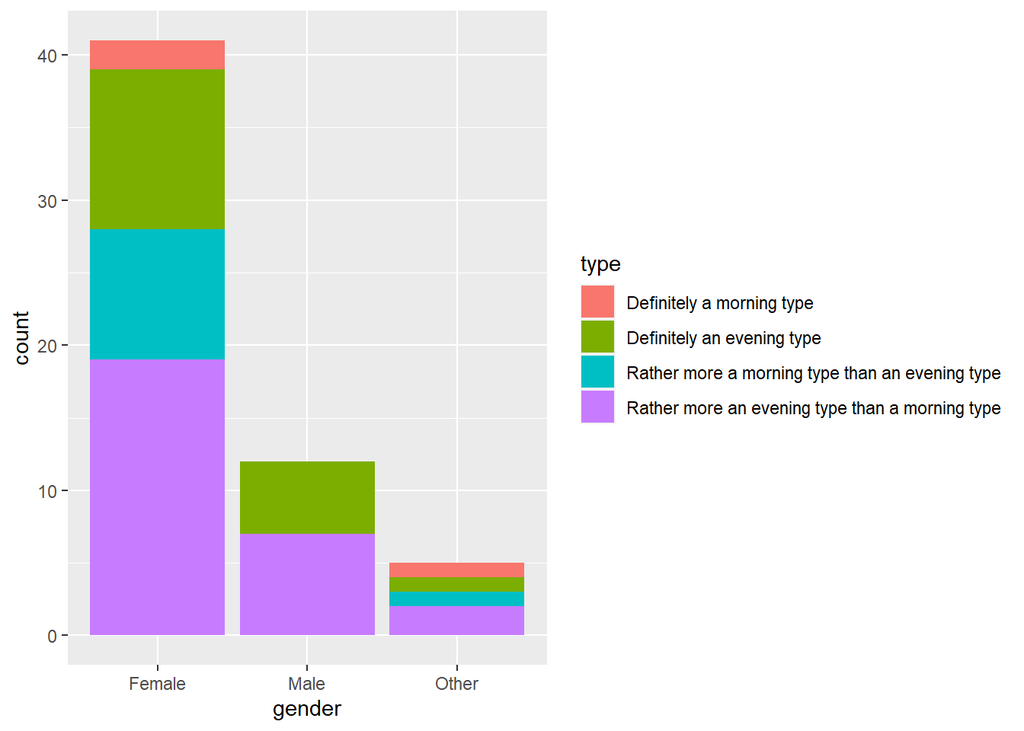

```r
bar_chart_gender <- summarize1 %>%
  group_by(gender) %>%
  ggplot(aes(x = gender,
         fill = type)) + geom_bar()

bar_chart_gender
```

END OF YOUR SOLUTION HERE

# Part 2

## Question 2.1

Link the `daily_sleep_log` with your demography and chrono type linked data. *hint* use `left_join` again.

YOUR SOLUTION HERE

```r
data2 <- left_join(daily_sleep_log, data1)
data2
```

```
## # A tibble: 927 × 27
##    date_record       sleep wake  sleep_date          sleep_time          sleep…¹
##    <chr>             <chr> <chr> <dttm>              <dttm>              <chr>
##  1 2023-01-04T00:40… 1899… 1899… 2023-01-04 00:00:00 1899-12-30 04:00:00 Wednes…
##  2 2023-01-04T09:40… 1899… 1899… 2023-01-04 00:00:00 1899-12-30 01:00:00 Wednes…
##  3 2023-01-04T09:55… 1899… 1899… 2023-01-04 00:00:00 1899-12-30 01:30:00 Wednes…
##  4 2023-01-04T10:36… 1899… 1899… 2023-01-04 00:00:00 1899-12-30 03:20:00 Wednes…
##  5 2023-01-04T10:48… 1899… 1899… 2023-01-04 00:00:00 1899-12-30 00:30:00 Wednes…
##  6 2023-01-04T10:52… 1899… 1899… 2023-01-04 00:00:00 1899-12-30 02:30:00 Wednes…
##  7 2023-01-04T10:57… 1899… 1899… 2023-01-04 00:00:00 1899-12-30 02:00:00 Wednes…
##  8 2023-01-04T10:59… 1899… 1899… 2023-01-03 00:00:00 1899-12-30 23:45:00 Tuesday
##  9 2023-01-04T10:59… 1899… 1899… 2023-01-04 00:00:00 1899-12-30 00:30:00 Wednes…
## 10 2023-01-04T11:30… 1899… 1899… 2023-01-04 00:00:00 1899-12-30 00:30:00 Wednes…
## # … with 917 more rows, 21 more variables: wake_date <dttm>, wake_time <dttm>,
## #   sleep_dt <chr>, wake_dt <chr>, time_slept_min <dbl>, time_slept_hour <dbl>,
## #   random_id <dbl>, gender <chr>, race <chr>, in_class <chr>, working <chr>,
## #   std_sleep_weekday <dttm>, std_wake_weekday <dttm>,
## #   hour_sleep_weekday <dbl>, hour_wake_up_weekday <dbl>,
## #   std_sleep_weekend <dttm>, std_wake_weekend <dttm>,
## #   hour_sleep_weekend <dbl>, hour_wake_up_weekend <dbl>, FeelBest <chr>, …
```

END OF YOUR SOLUTION HERE

## Question 2.2

Compare the Sleep time of Seattle Metro from the ATUS to our Class Average. Does it look like our class is sleeping a similar amount of time?

YOUR SOLUTION HERE

```r
data2<- data2 %>%
  select(time_slept_min)

sea_met_sleep <- atus_metro %>%
  select(location, BLS_PCARE_SLEEP) %>%
  filter(location == "Seattle Metro")

summarize2 <- data2 %>%
  summarise(average = mean(time_slept_min))

summarize3 <- sea_met_sleep %>%
  summarise(average = mean(BLS_PCARE_SLEEP))
```

Compare the Sleep time of Seattle Metro from the ATUS to our Class Average. Does it look like our class is sleeping a similar amount of time?

Our class average sleep time is 454.95 minutes, or 7.58 hours. The average sleep time for all of Seattle Metro is 527.32 minutes, or 8.79 hours.

END OF YOUR SOLUTION HERE

## Question 2.3

Plot average time slept by day and gender.

YOUR SOLUTION HERE

```r
# Make the chart
data3 <- left_join(daily_sleep_log, data1)

# Select relevant columns and rename columns
data3 <- data3 %>%
  select(sleep_date, gender, time_slept_hour) %>%
  rename(date = sleep_date, hours_slept = time_slept_hour) %>%
# Group by date and gender
  group_by(date, gender) %>%
# Summarize the average time slept for each gender category
  summarise(average_slept = mean(hours_slept))

data3
```

```
## # A tibble: 77 × 3
## # Groups:   date [26]
##    date                gender average_slept
##    <dttm>              <chr>          <dbl>
##  1 2023-01-03 00:00:00 Female          8.00
##  2 2023-01-03 00:00:00 Other           9
##  3 2023-01-04 00:00:00 Female          7.12
##  4 2023-01-04 00:00:00 Male            6.35
##  5 2023-01-04 00:00:00 Other           6.68
##  6 2023-01-05 00:00:00 Female          7.80
##  7 2023-01-05 00:00:00 Male            7.37
##  8 2023-01-05 00:00:00 Other           7.07
##  9 2023-01-06 00:00:00 Female          7.90
## 10 2023-01-06 00:00:00 Male            6.30
## # … with 67 more rows
```

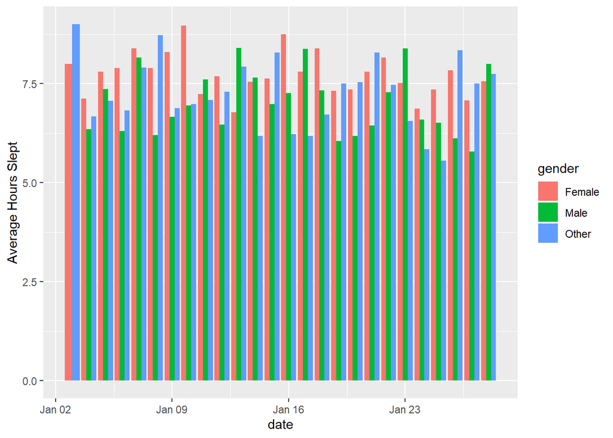

```r
# Make a grouped bar chart
library(ggplot2)

ggplot(data = data3,
       aes(x = date,
           y = average_slept,
           fill = gender)) + geom_bar(
             stat = "identity",
             position = "dodge") + ylab("Average Hours Slept")
```

END OF YOUR SOLUTION HERE

# Question 3

Come up with a plot not thought of in this lab to illustrate a feature of the data you find interesting.

- Step one: Pose a question (that can be answered with our survey data)
- Step two: Build your data set that can answer from our survey data
- Step three: Plot it
- Step four: Interpret your graph

YOUR SOLUTION HERE

*Question*: What are the average hours slept for people who are working vs. people who aren’t?

```r
# Make dataset

data4 <- left_join(daily_sleep_log, data1)

# Select relevant columns
data4 <- data4 %>%
  select(sleep_date, working, time_slept_hour) %>%
# Rename column for easier typing
  rename(date = sleep_date, hours_slept = time_slept_hour) %>%
# Group by date and working status
  group_by(date, working) %>%
# Summarize average time slept
  summarise(mean(hours_slept)) %>%
# Rename column for easier typing
  rename(average = "mean(hours_slept)")

data4
```

```
## # A tibble: 52 × 3
## # Groups:   date [26]
##    date                working average
##    <dttm>              <chr>     <dbl>
##  1 2023-01-03 00:00:00 No         8.53
##  2 2023-01-03 00:00:00 Yes        7.98
##  3 2023-01-04 00:00:00 No         6.46
##  4 2023-01-04 00:00:00 Yes        7.25
##  5 2023-01-05 00:00:00 No         6.87
##  6 2023-01-05 00:00:00 Yes        8.23
##  7 2023-01-06 00:00:00 No         6.75
##  8 2023-01-06 00:00:00 Yes        7.83
##  9 2023-01-07 00:00:00 No         8.24
## 10 2023-01-07 00:00:00 Yes        8.35
## # … with 42 more rows
```

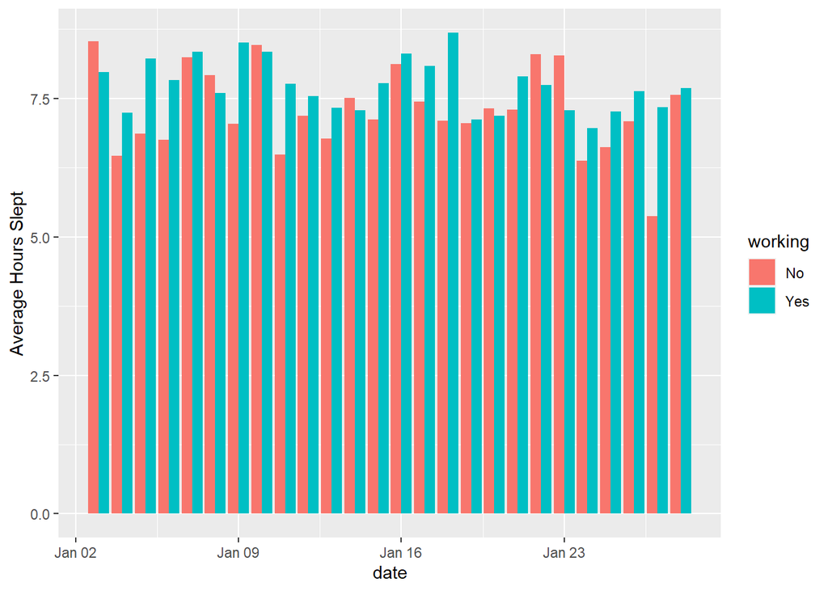

```r
# Plot the data

ggplot(data = data4,
       aes(x = date,
           y = average,
           fill = working)) + geom_bar(
             stat = "identity",
             position = "dodge") + ylab("Average Hours Slept")
```

END OF YOUR SOLUTION HERE